# TareaANOVA.Rmd

F. A. Barrios Instituto de Neurobiología, UNAM

2020-10-26

# 1 Examples Chapter 8 Daniel ANOVA

Solution of some examples and exercises from Daniel’s book, the ANOVA chapter. As part of the Homework we include R code in the document, and the R code will be included too.

## 1.1 Example 8.2.1

Game meats, including those from white-tailed deer and eastern gray squirrels, are used as food by families, hunters and other individuals for health, cultural, or personal reasons. A study by D Holben assessed the selenium content of the meat from free-roaming white-tailed deer (venison) and gray squirrel (squirrel) obtained from a low selenium region of the United States. These selenium content values were also compared to those of beef produced whithin and outside the same region. We want to know if the selenium levels are different in the four meat groups.

```r
setwd("~/Dropbox/Fdo/ClaseStats/RegressionClass/RegressionR_code")
# Example Chap 8, One-Way ANOVA
Exa8_2=read.csv(file="DataOther/EXA_C08_S02_01.csv", header=TRUE)
summary(Exa8_2)
```

```
      VEN             SQU             RRB             NRB
 Min.   : 8.70   Min.   : 4.55   Min.   : 9.69   Min.   :  4.45
 1st Qu.:21.37   1st Qu.:32.00   1st Qu.:22.35   1st Qu.: 46.34
 Median :26.30   Median :40.23   Median :28.94   Median : 66.36
 Mean   :25.88   Mean   :43.25   Mean   :29.08   Mean   : 62.05
 3rd Qu.:31.43   3rd Qu.:55.32   3rd Qu.:34.91   3rd Qu.: 75.79
 Max.   :45.08   Max.   :87.50   Max.   :56.61   Max.   :139.09
 NA's   :11      NA's   :23                      NA's   :34
```

```r
boxplot(Exa8_2)
Exa8_2.dat = stack(Exa8_2)
names(Exa8_2.dat)
```

```
[1] "values" "ind"
```

```r
Exa8_2.aov=aov(values~ind, data=Exa8_2.dat)
summary(Exa8_2.aov)
```

```
             Df Sum Sq Mean Sq F value   Pr(>F)
ind           3  21262    7087      27 7.68e-14 ***
Residuals   140  36747     262
---
Signif. codes:  0 '***' 0.001 '**' 0.01 '*' 0.05 '.' 0.1 ' ' 1
68 observations deleted due to missingness
```

```r
# # # # # # # # # # # # # # # # #
plot(values~ind, data=Exa8_2.dat)
TukeyHSD(Exa8_2.aov, ordered=TRUE)
```

```
  Tukey multiple comparisons of means
    95% family-wise confidence level
    factor levels have been ordered

Fit: aov(formula = values ~ ind, data = Exa8_2.dat)

$ind
             diff       lwr      upr     p adj
RRB-VEN  3.207543 -5.495016 11.91010 0.7732308
SQU-VEN 17.370190  7.300208 27.44017 0.0000881
NRB-VEN 36.170840 24.523916 47.81776 0.0000000
SQU-RRB 14.162648  4.537925 23.78737 0.0011105
NRB-RRB 32.963297 21.699125 44.22747 0.0000000
NRB-SQU 18.800649  6.449472 31.15183 0.0006857
```

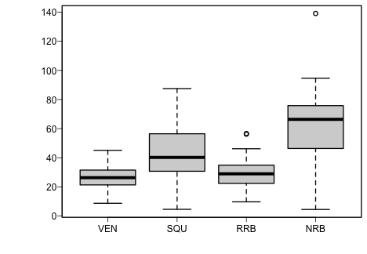

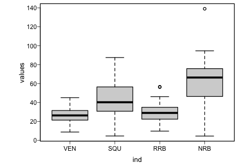

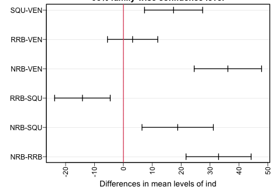

[figure not shown]

```r
plot(TukeyHSD(Exa8_2.aov), las=2)
abline(v=0, col=2)
```

## 1.2 Example 8.3.1

```r
# Build a table, index by index since
# Two-Way ANOVA EXAMPLE 8.3.1 has NO-data file
# Therefore we make the example table.
#
Age=factor(rep(c(1,2,3,4,5), 3))
Age
```

```
 [1] 1 2 3 4 5 1 2 3 4 5 1 2 3 4 5
Levels: 1 2 3 4 5
```

```r
Method=factor(rep(1:3,c(5,5,5)))
Method
```

```
 [1] 1 1 1 1 1 2 2 2 2 2 3 3 3 3 3
Levels: 1 2 3
```

```r
levels(Method)=letters[1:3]
Method
```

```
 [1] a a a a a b b b b b c c c c c
Levels: a b c
```

```r
t = c(7,8,9,10,11,9,9,9,9,12,10,10,12,12,14)
#
plot(t ~ Age + Method)
# now the ANOVA model
t_aov = aov(t ~ Method + Age)
summary(t_aov)
```

```
            Df Sum Sq Mean Sq F value   Pr(>F)
Method       2 18.533   9.267   21.39 0.000617 ***
Age          4 24.933   6.233   14.38 0.001002 **
Residuals    8  3.467   0.433
---
Signif. codes:  0 '***' 0.001 '**' 0.01 '*' 0.05 '.' 0.1 ' ' 1
```

```r
layout(matrix(c(1,2), nrow=2, ncol=1, byrow=TRUE))
TukeyHSD(t_aov)
```

```
  Tukey multiple comparisons of means
    95% family-wise confidence level

Fit: aov(formula = t ~ Method + Age)

$Method
    diff        lwr      upr     p adj
b-a  0.6 -0.5896489 1.789649 0.3666717
c-a  2.6  1.4103511 3.789649 0.0006358
c-b  2.0  0.8103511 3.189649 0.0034083

$Age
         diff        lwr      upr     p adj
2-1 0.3333333 -1.5235390 2.190206 0.9676094
3-1 1.3333333 -0.5235390 3.190206 0.1877558
4-1 1.6666667 -0.1902056 3.523539 0.0810838
5-1 3.6666667  1.8097944 5.523539 0.0009146
3-2 1.0000000 -0.8568723 2.856872 0.4057524
4-2 1.3333333 -0.5235390 3.190206 0.1877558
5-2 3.3333333  1.4764610 5.190206 0.0017351
4-3 0.3333333 -1.5235390 2.190206 0.9676094
5-3 2.3333333  0.4764610 4.190206 0.0154324
5-4 2.0000000  0.1431277 3.856872 0.0348816
```

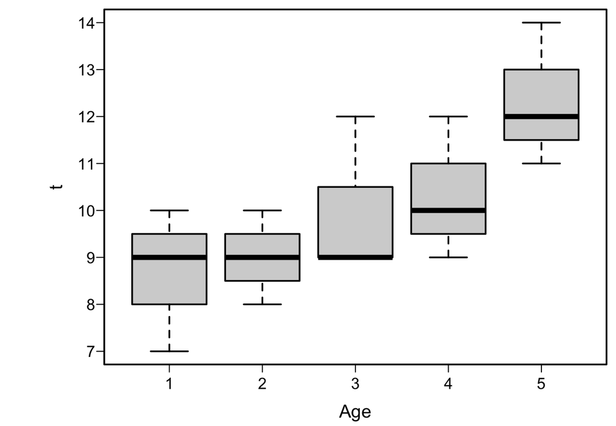

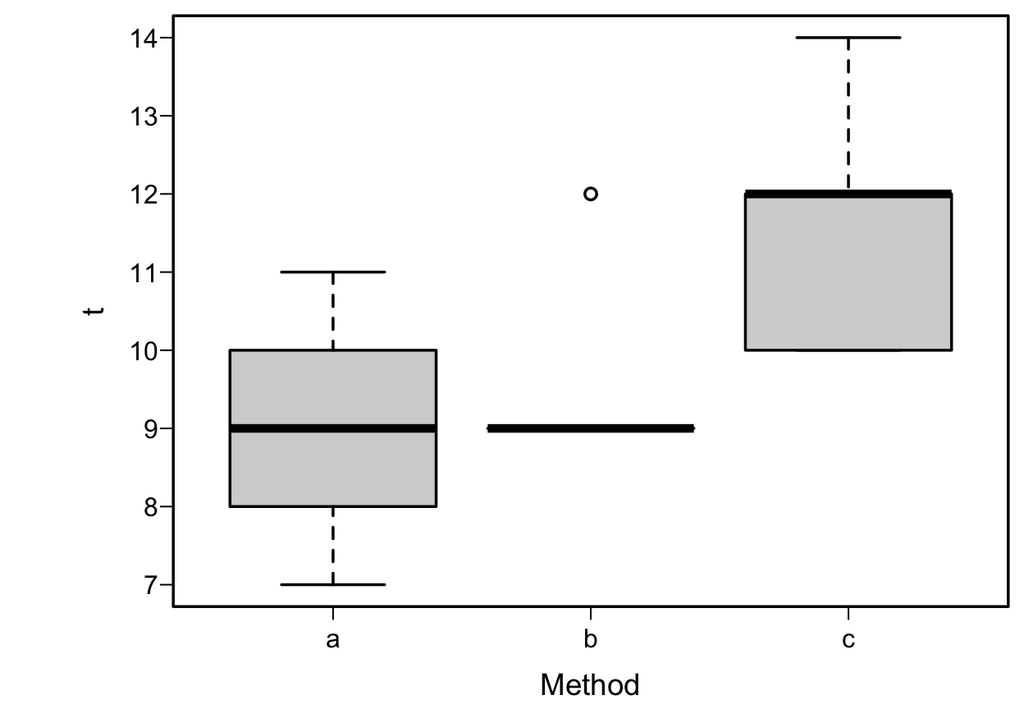

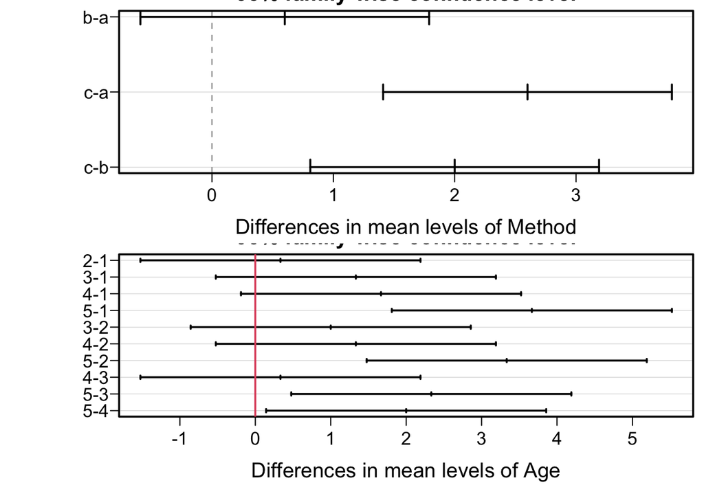

```r
plot(TukeyHSD(t_aov))
abline(v=0, col=2)
```

Layout instruction divides the graphical screen in four sections, square diff and QQ-plot graphs.

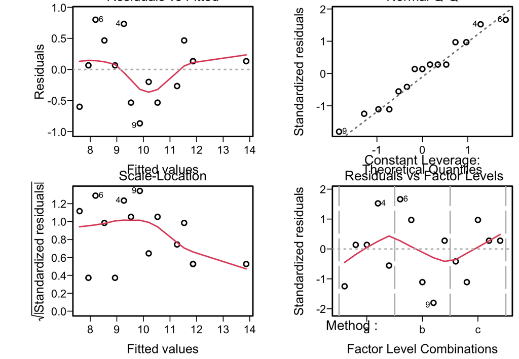

```r
layout(matrix(c(1, 2, 3, 4), nrow=2, ncol=2, byrow=TRUE))
plot(t_aov)
```

## 1.3 Example 8.4.1

Licciardone et al. examined subjects with chronic, nonspecific low back pain. In this study, 18 of the subjects completed a survey questionnaire assessing physical functioning at baseline, and after 1, 3, and 6 months. The file has data for these subjects which received a sham treatment thet appeared to be genuine osteopathic manipulations. Higher values indicate better physical functioning. Higher values indicate better physical functioning. The goal of the experiment was to determine if subjects would report improvement over time even though the treatment they received would provide minimal improvement. We wish to know if there is a difference in the mean survey values among the four points in time.

```r
setwd("~/Dropbox/Fdo/ClaseStats/RegressionClass/RegressionR_code")
# Example 8.4.1 ANOVA Single factor repeated measures
#
Exa4.1=read.csv(file="DataOther/EXA_C08_S04_01mod.csv", header=TRUE)
names(Exa4.1)
```

```
[1] "Assessment" "Time"       "Subject"
```

```r
# FUNC we want to estimate if depends on SUBJ with
# repeated measurements for SUBJ.
# factor is used to force the numbers as factors !
# And were grouped in time to measure effect
# model FUNC ~ factor(TIME) + factor(SUBJ)
# layout(matrix(c(1,2), nrow=2, ncol=1, byrow=TRUE))
plot(Assessment ~ factor(Time) + factor(Subject), data=Exa4.1)
Exa4.1.aov = aov(Assessment ~ factor(Time) + factor(Subject), data=Exa4.1)
summary(Exa4.1.aov)
```

```
                Df Sum Sq Mean Sq F value   Pr(>F)
factor(Time)     3   2396   798.6   5.501  0.00237 **
factor(Subject) 17  20238  1190.4   8.200 2.18e-09 ***
Residuals       51   7404   145.2
---
Signif. codes:  0 '***' 0.001 '**' 0.01 '*' 0.05 '.' 0.1 ' ' 1
```

```r
TukeyHSD(Exa4.1.aov)
```

```
  Tukey multiple comparisons of means
    95% family-wise confidence level

Fit: aov(formula = Assessment ~ factor(Time) + factor(Subject), data = Exa4.1)

$`factor(Time)`
                     diff         lwr       upr     p adj
Month1-Baseline -2.500000 -13.1666579  8.166658 0.9244135
Month3-Baseline 11.666667   1.0000088 22.333325 0.0269476
Month6-Baseline  8.055556  -2.6111023 18.722213 0.1993649
Month3-Month1   14.166667   3.5000088 24.833325 0.0048300
Month6-Month1   10.555556  -0.1111023 21.222213 0.0534057
Month6-Month3   -3.611111 -14.2777690  7.055547 0.8053159

$`factor(Subject)`
               diff           lwr          upr     p adj
2-1    1.000000e+01  -21.28918619  41.28918619 0.9991367
3-1   -3.000000e+01  -61.28918619   1.28918619 0.0737815
4-1   -2.500000e+01  -56.28918619   6.28918619 0.2705596
5-1   -8.750000e+00  -40.03918619  22.53918619 0.9998418
6-1   -1.250000e+01  -43.78918619  18.78918619 0.9894152
7-1   -2.500000e+00  -33.78918619  28.78918619 1.0000000
8-1   -1.625000e+01  -47.53918619  15.03918619 0.8957133
9-1   -1.000000e+01  -41.28918619  21.28918619 0.9991367
10-1  -3.375000e+01  -65.03918619  -2.46081381 0.0226473
11-1  -7.500000e+00  -38.78918619  23.78918619 0.9999807
12-1  -2.625000e+01  -57.53918619   5.03918619 0.2025154
13-1  -1.875000e+01  -50.03918619  12.53918619 0.7439419
14-1  -1.000000e+01  -41.28918619  21.28918619 0.9991367
15-1  -1.500000e+01  -46.28918619  16.28918619 0.9435248
16-1  -6.125000e+01  -92.53918619 -29.96081381 0.0000004
17-1  -4.500000e+01  -76.28918619 -13.71081381 0.0003441
18-1  -2.500000e+00  -33.78918619  28.78918619 1.0000000
3-2   -4.000000e+01  -71.28918619  -8.71081381 0.0024187
4-2   -3.500000e+01  -66.28918619  -3.71081381 0.0148202
5-2   -1.875000e+01  -50.03918619  12.53918619 0.7439419
6-2   -2.250000e+01  -53.78918619   8.78918619 0.4446866
7-2   -1.250000e+01  -43.78918619  18.78918619 0.9894152
8-2   -2.625000e+01  -57.53918619   5.03918619 0.2025154
9-2   -2.000000e+01  -51.28918619  11.28918619 0.6471493
```

[output cut: 114 more lines]

```
14-13  8.750000e+00  -22.53918619  40.03918619 0.9998418
15-13  3.750000e+00  -27.53918619  35.03918619 1.0000000
16-13 -4.250000e+01  -73.78918619 -11.21081381 0.0009248
17-13 -2.625000e+01  -57.53918619   5.03918619 0.2025154
18-13  1.625000e+01  -15.03918619  47.53918619 0.8957133
15-14 -5.000000e+00  -36.28918619  26.28918619 1.0000000
16-14 -5.125000e+01  -82.53918619 -19.96081381 0.0000267
17-14 -3.500000e+01  -66.28918619  -3.71081381 0.0148202
18-14  7.500000e+00  -23.78918619  38.78918619 0.9999807
16-15 -4.625000e+01  -77.53918619 -14.96081381 0.0002081
17-15 -3.000000e+01  -61.28918619   1.28918619 0.0737815
18-15  1.250000e+01  -18.78918619  43.78918619 0.9894152
17-16  1.625000e+01  -15.03918619  47.53918619 0.8957133
18-16  5.875000e+01   27.46081381  90.03918619 0.0000011
18-17  4.250000e+01   11.21081381  73.78918619 0.0009248
```

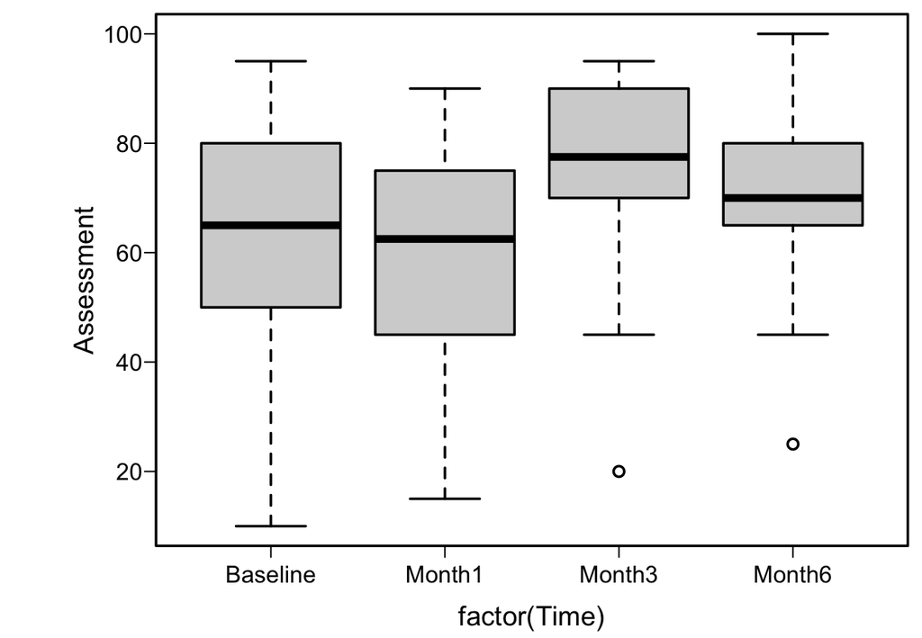

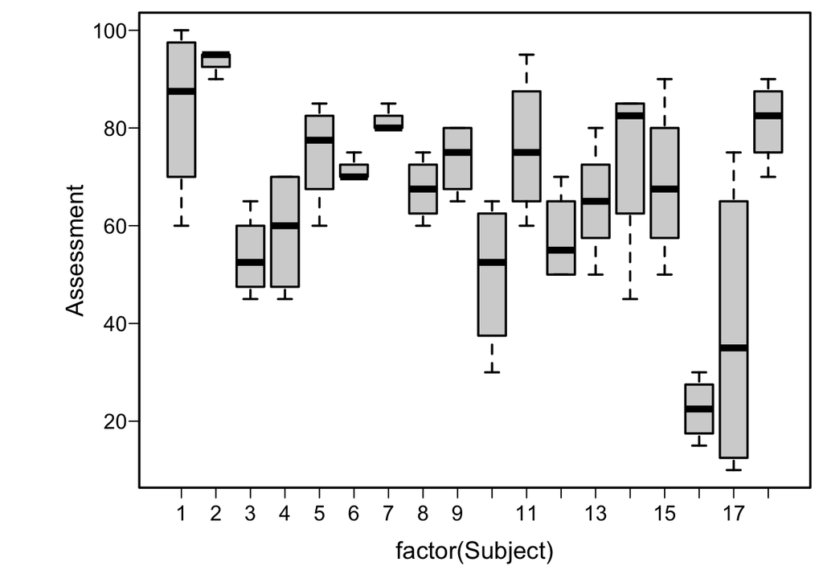

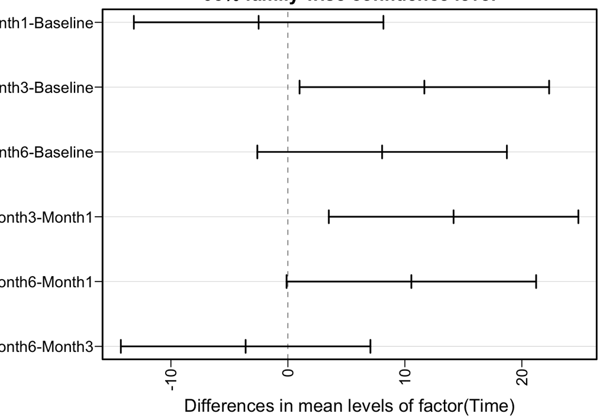

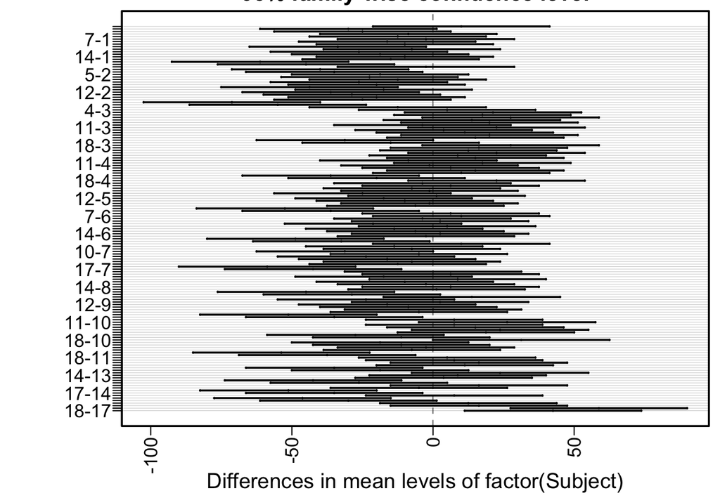

```r
plot(TukeyHSD(Exa4.1.aov), las=2)
```

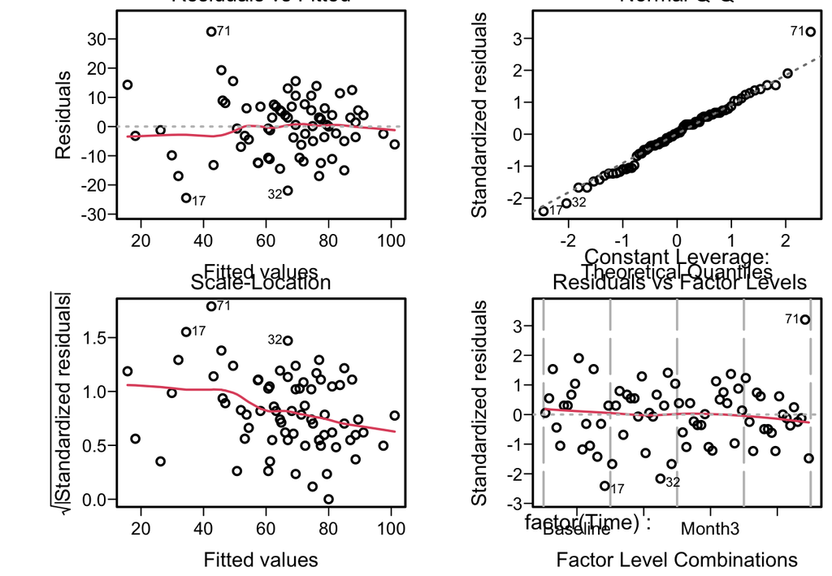

```r
layout(matrix(c(1,2,3,4), nrow=2, ncol=2, byrow=TRUE))
plot(Exa4.1.aov)
```

# 2 Exercises chapter 8 Daniel

In the following exercises estimate an ANOVA model. Let $\alpha = 0.05$ for each tes. Use Tukey’s HSD procedure to test for significant differences among individual pairs of means (if appropriate). Construct box-plots of the data.

## 2.1 EXERCISE 8.2.1

Reseachers at CWRU wanted to develop and implement a transducer, manageable in a clinical detting, for quialifying isometric moment produced at the elbow joint by individuals with tetraplegia (paralysis or paresis of all four limbs). The apparatus, called an elbow moment transducer (EMT), measures the force the elbow can exert when flexing. The output variable is voltage. The machine was tested at four different elbow extension angles, 30, 60, 90, 102 degrees, on a mock elbow consisting of two hinged aluminum beams. The data is at file.

```r
setwd("~/Dropbox/Fdo/ClaseStats/RegressionClass/RegressionR_code")
# Problem 8.2.1
Exr8.2.1=read.csv(file="DataOther/EXR_C08_S02_01.csv", header=TRUE)
names(Exr8.2.1)
```

```
[1] "EMT"   "ANGLE"
```

```r
boxplot(Exr8.2.1)
is.factor(Exr8.2.1$ANGLE)
```

```
[1] FALSE
```

```r
# boxplot does not work . . .
# ANGLE are numbers and no lavels, so the factor command
# is needed to force the ANGLE numbers as factors !
plot(EMT ~ factor(ANGLE), data=Exr8.2.1)
Exr2_1.aov = aov(EMT ~ factor(ANGLE), data=Exr8.2.1)
summary(Exr2_1.aov)
```

```
               Df Sum Sq Mean Sq F value   Pr(>F)
factor(ANGLE)   3   20.0   6.669   6.242 0.000393 ***
Residuals     325  347.2   1.068
---
Signif. codes:  0 '***' 0.001 '**' 0.01 '*' 0.05 '.' 0.1 ' ' 1
```

```r
TukeyHSD(Exr2_1.aov)
```

```
  Tukey multiple comparisons of means
    95% family-wise confidence level

Fit: aov(formula = EMT ~ factor(ANGLE), data = Exr8.2.1)

$`factor(ANGLE)`
            diff        lwr        upr     p adj
2-1 -0.447587615 -1.0125162  0.1173410 0.1734399
3-1  0.191059839 -0.1830744  0.5651941 0.5516339
4-1 -0.443557312 -1.0084859  0.1213713 0.1799776
3-2  0.638647454  0.1360387  1.1412562 0.0062693
4-2  0.004030303 -0.6530720  0.6611326 0.9999986
4-3 -0.634617151 -1.1372259 -0.1320084 0.0067138
```

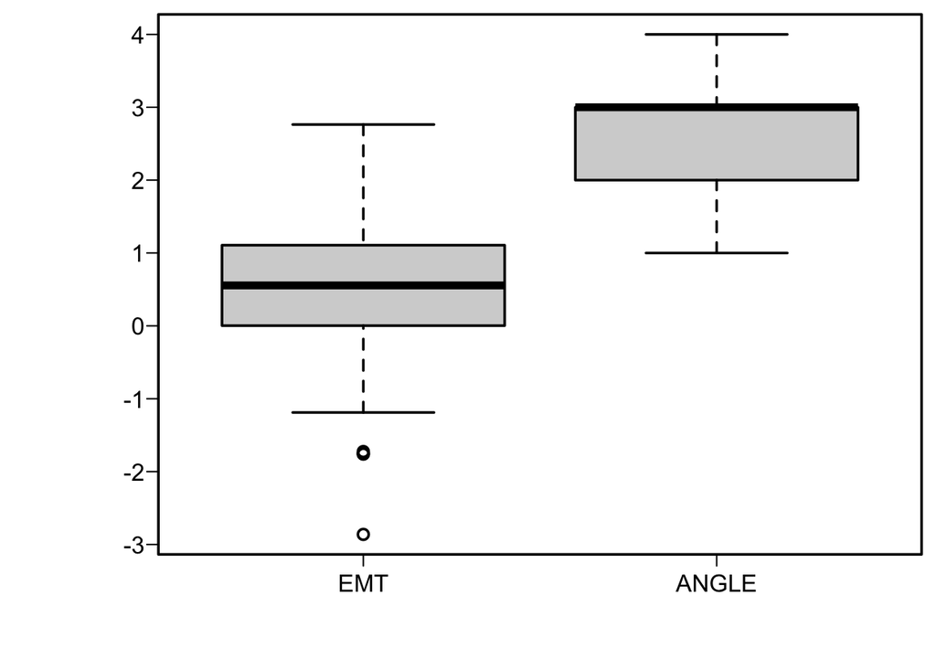

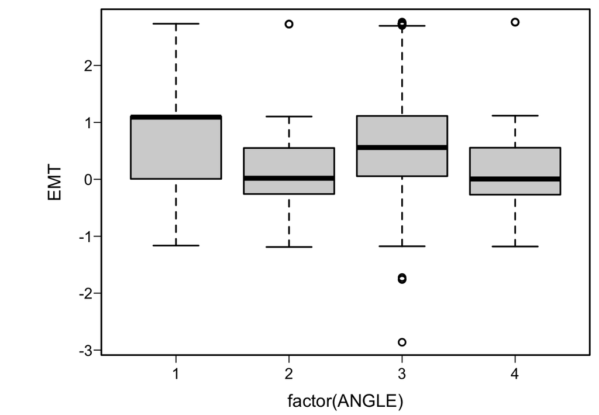

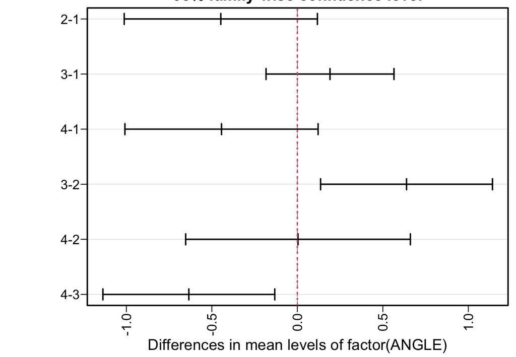

```r
plot(TukeyHSD(Exr2_1.aov), las=2)
abline(v=0., lty=3, col=2)
```

## 2.2 EXERCISE 8.2.3

Ilich-Ernst et al. investigated dietary intake of calcium among a cross section of 113 healthy women ages 20-88. The researchers formed four age groupings as follows: Group A, 20.0 - 45.9 years; Group B, 46.0 - 55.9 years; Group C, 56.0 - 65.9 years; and Group D, over 66 years. Calcium from food intake was measured in mg/day. The data is at the file.

```r
setwd("~/Dropbox/Fdo/ClaseStats/RegressionClass/RegressionR_code")
# Problem 8.2.3 Consumo de Calcio en dieta de 113 mujeres
# cuatro grupos por edad 20-45, 46-55, 56-65, 66-88
Er8.2.3=read.csv(file="DataOther/EXR_C08_S02_03.csv", header=TRUE)
names(Er8.2.3)
```

```
[1] "calcium" "Group"
```

```r
plot(calcium ~ factor(Group), data=Er8.2.3)
aovEr8.2.3 = aov(calcium ~ factor(Group), data=Er8.2.3)
summary(aovEr8.2.3)
```

```
               Df   Sum Sq Mean Sq F value   Pr(>F)
factor(Group)   3  5931208 1977069   9.359 1.48e-05 ***
Residuals     109 23026500  211252
---
Signif. codes:  0 '***' 0.001 '**' 0.01 '*' 0.05 '.' 0.1 ' ' 1
```

```r
#
TukeyHSD(aovEr8.2.3)
```

```
  Tukey multiple comparisons of means
    95% family-wise confidence level

Fit: aov(formula = calcium ~ factor(Group), data = Er8.2.3)

$`factor(Group)`
          diff       lwr        upr     p adj
B-A -455.72078 -865.7066  -45.73492 0.0230454
C-A -574.53605 -913.5892 -235.48294 0.0001356
D-A -596.63447 -905.3867 -287.88228 0.0000109
C-B -118.81527 -509.0844  271.45386 0.8568796
D-B -140.91369 -505.1676  223.34020 0.7443051
D-C  -22.09842 -304.1436  259.94679 0.9969598
```

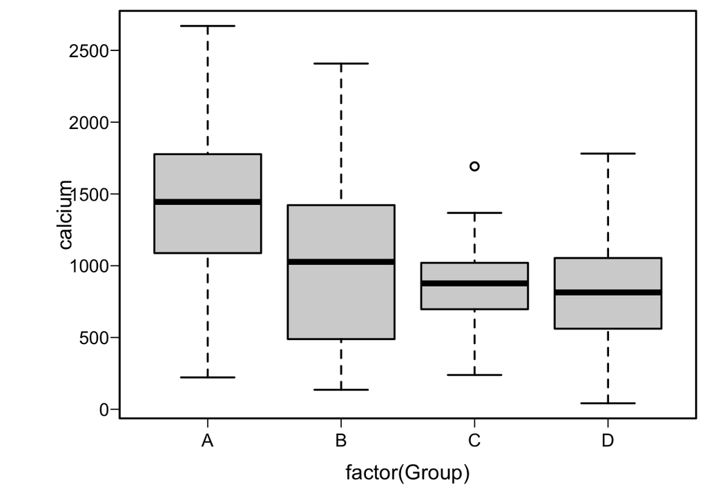

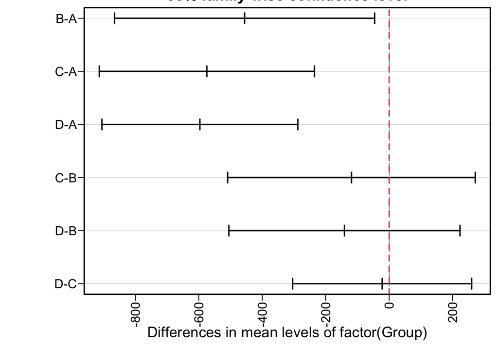

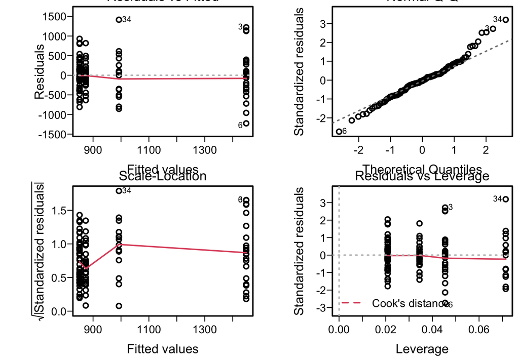

```r
plot(TukeyHSD(aovEr8.2.3), las=2)
abline(v=0, col=2, lty=2)
# For Q-Q test and square diff.
layout(matrix(c(1,2,3,4), nrow=2, ncol=2, byrow=TRUE))
plot(aovEr8.2.3)
```

## EXERCISE 8.3.1

The objective of a study by Brooks et al. was to evaluate the efficacy of using a virtual kitchen for vocational training of people with learning disabilities. Twenty-four students participated in the study. Each participant performed four food preparations tasks and they were scored on the quality of the preparation. Then each participant received regular vocational training in food preparation (real training), visual training using a TV and computer screen of a typical kitchen, work-book training with specialized reading materilas, and no training (to serve as control). After eah of these trainigs, the subjects were tested on food preparation. Improvement scores for each of the four training methods are presented in the file. Afetr eliminating subject effects, can we conclude that the improvement scores differ among mathods of training? Let $\alpha = .05$.

```r
setwd("~/Dropbox/Fdo/ClaseStats/RegressionClass/RegressionR_code")
# Problem 8.3.1 two-way ANOVA exercise
Exr8.3.1=read.csv(file="DataOther/EXR_C08_S03_01.csv", header=TRUE)
names(Exr8.3.1)
```

```
[1] "subject" "score"   "type"
```

```r
# TYPE are numbers and the factor command is needed to
# force the numbers as factors !
# levels(Exr8.3.1$type)=letters[1:4]
layout(matrix(c(1,2), nrow=2, ncol=1, byrow=TRUE))
plot(score ~ factor(type) + factor(subject), data=Exr8.3.1)
Exr3_1.aov = aov(score ~ factor(type) + factor(subject), data=Exr8.3.1)
summary(Exr3_1.aov)
```

```
                Df Sum Sq Mean Sq F value   Pr(>F)
factor(type)     3  498.4  166.13  19.793 2.31e-09 ***
factor(subject) 23  481.1   20.92   2.492  0.00189 **
Residuals       69  579.1    8.39
---
Signif. codes:  0 '***' 0.001 '**' 0.01 '*' 0.05 '.' 0.1 ' ' 1
```

```r
TukeyHSD(Exr3_1.aov)
```

```
  Tukey multiple comparisons of means
    95% family-wise confidence level

Fit: aov(formula = score ~ factor(type) + factor(subject), data = Exr8.3.1)

$`factor(type)`
         diff        lwr        upr     p adj
2-1  1.791667 -0.4101579  3.9934912 0.1501221
3-1 -3.000000 -5.2018245 -0.7981755 0.0033972
4-1 -3.875000 -6.0768245 -1.6731755 0.0000955
3-2 -4.791667 -6.9934912 -2.5898421 0.0000014
4-2 -5.666667 -7.8684912 -3.4648421 0.0000000
4-3 -0.875000 -3.0768245  1.3268245 0.7229517

$`factor(subject)`
               diff         lwr        upr     p adj
2-1   -3.996803e-15  -7.7598393  7.7598393 1.0000000
3-1    2.000000e+00  -5.7598393  9.7598393 0.9999978
4-1    2.500000e+00  -5.2598393 10.2598393 0.9998920
5-1    3.500000e+00  -4.2598393 11.2598393 0.9875296
6-1   -7.500000e-01  -8.5098393  7.0098393 1.0000000
7-1    6.250000e+00  -1.5098393 14.0098393 0.2938362
8-1    1.000000e+00  -6.7598393  8.7598393 1.0000000
9-1    2.750000e+00  -5.0098393 10.5098393 0.9995181
10-1   2.750000e+00  -5.0098393 10.5098393 0.9995181
11-1   6.250000e+00  -1.5098393 14.0098393 0.2938362
12-1   6.250000e+00  -1.5098393 14.0098393 0.2938362
13-1   2.000000e+00  -5.7598393  9.7598393 0.9999978
14-1   2.750000e+00  -5.0098393 10.5098393 0.9995181
15-1   2.250000e+00  -5.5098393 10.0098393 0.9999816
16-1   5.250000e+00  -2.5098393 13.0098393 0.6269765
17-1   2.750000e+00  -5.0098393 10.5098393 0.9995181
18-1   4.884981e-15  -7.7598393  7.7598393 1.0000000
19-1  -2.250000e+00 -10.0098393  5.5098393 0.9999816
20-1  -1.000000e+00  -8.7598393  6.7598393 1.0000000
21-1   3.750000e+00  -4.0098393 11.5098393 0.9730185
22-1   2.750000e+00  -5.0098393 10.5098393 0.9995181
23-1   1.500000e+00  -6.2598393  9.2598393 1.0000000
24-1   3.250000e+00  -4.5098393 11.0098393 0.9949874
3-2    2.000000e+00  -5.7598393  9.7598393 0.9999978
```

[output cut: 237 more lines]

```
20-19  1.250000e+00  -6.5098393  9.0098393 1.0000000
21-19  6.000000e+00  -1.7598393 13.7598393 0.3678350
22-19  5.000000e+00  -2.7598393 12.7598393 0.7130567
23-19  3.750000e+00  -4.0098393 11.5098393 0.9730185
24-19  5.500000e+00  -2.2598393 13.2598393 0.5377759
21-20  4.750000e+00  -3.0098393 12.5098393 0.7913317
22-20  3.750000e+00  -4.0098393 11.5098393 0.9730185
23-20  2.500000e+00  -5.2598393 10.2598393 0.9998920
24-20  4.250000e+00  -3.5098393 12.0098393 0.9103202
22-21 -1.000000e+00  -8.7598393  6.7598393 1.0000000
23-21 -2.250000e+00 -10.0098393  5.5098393 0.9999816
24-21 -5.000000e-01  -8.2598393  7.2598393 1.0000000
23-22 -1.250000e+00  -9.0098393  6.5098393 1.0000000
24-22  5.000000e-01  -7.2598393  8.2598393 1.0000000
24-23  1.750000e+00  -6.0098393  9.5098393 0.9999998
```

```
Analysis of Variance Table

Model 1: score ~ factor(type) + factor(subject)
Model 2: score ~ factor(subject)
  Res.Df     RSS Df Sum of Sq      F    Pr(>F)
1     69  579.12
2     72 1077.50 -3   -498.38 19.793 2.306e-09 ***
---
Signif. codes:  0 '***' 0.001 '**' 0.01 '*' 0.05 '.' 0.1 ' ' 1
```

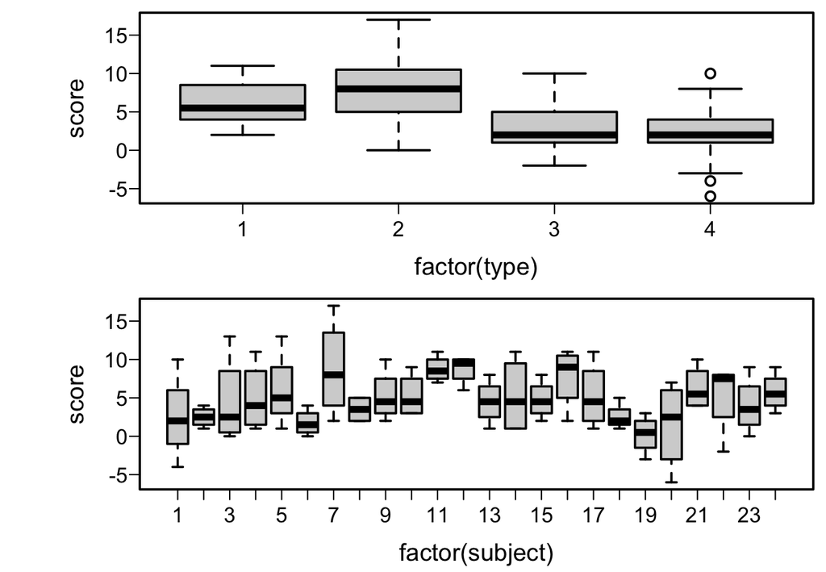

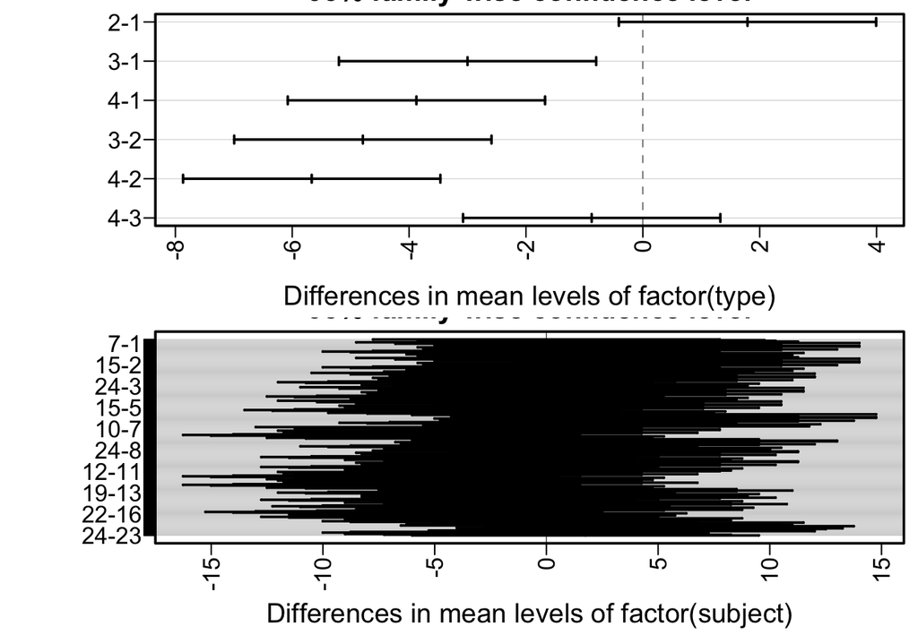

```r
layout(matrix(c(1,2), nrow=2, ncol=1))
plot(TukeyHSD(Exr3_1.aov), las=2)
# with a linear model
res.add = lm(score ~ factor(type) + factor(subject), data= Exr8.3.1)
res.notype = lm(score ~ factor(subject), data= Exr8.3.1)
anova(res.add, res.notype)
```

## EXERCISE 8.3.2

McConville et al. report the effects of chewing one piece of nicotine gum (containing 2 mg nicotine) on tic frecuency in patients whose Tourette’s disorder was inadequately controlled by haloperidol. The frecuencies under four conditions are in the table in the file. After eliminating patient effects, can we conclude that the mean number of tics differs among the four condifions? let $\alpha = .01$.

```r
setwd("~/Dropbox/Fdo/ClaseStats/RegressionClass/RegressionR_code")
# Problem 8.3.2 two-way ANOVA exercise
Exr3.2=read.csv(file="DataOther/EXR_C08_S03_02.mod.csv", header=TRUE)
names(Exr3.2)
```

```
[1] "Resp"    "Time"    "PATIENT"
```

```r
# PATIENT are numbers and the factor command is needed to force the
# numbers as factors !
layout(matrix(c(1,2),nrow=1, ncol=2))
plot(Resp ~ factor(PATIENT) + factor(Time), data=Exr3.2)
Exr3_2.aov = aov(Resp ~ factor(PATIENT) + factor(Time), data=Exr3.2)
summary(Exr3_2.aov)
```

```
                Df  Sum Sq Mean Sq F value   Pr(>F)
factor(PATIENT)  9 1694868  188319  24.116 1.12e-10 ***
factor(Time)     3  153813   51271   6.566  0.00178 **
Residuals       27  210839    7809
---
Signif. codes:  0 '***' 0.001 '**' 0.01 '*' 0.05 '.' 0.1 ' ' 1
```

```r
TukeyHSD(Exr3_2.aov, conf.level=0.99)
```

```
  Tukey multiple comparisons of means
    99% family-wise confidence level

Fit: aov(formula = Resp ~ factor(PATIENT) + factor(Time), data = Exr3.2)

$`factor(PATIENT)`
        diff        lwr        upr     p adj
2-1   660.00  402.50448  917.49552 0.0000000
3-1   -76.50 -333.99552  180.99552 0.9616014
4-1   269.25   11.75448  526.74552 0.0062652
5-1    86.75 -170.74552  344.24552 0.9205014
6-1    63.25 -194.24552  320.74552 0.9888604
7-1   128.25 -129.24552  385.74552 0.5727927
8-1   -59.75 -317.24552  197.74552 0.9925152
9-1   218.00  -39.49552  475.49552 0.0447774
10-1  274.00   16.50448  531.49552 0.0051764
3-2  -736.50 -993.99552 -479.00448 0.0000000
4-2  -390.75 -648.24552 -133.25448 0.0000419
5-2  -573.25 -830.74552 -315.75448 0.0000000
6-2  -596.75 -854.24552 -339.25448 0.0000000
7-2  -531.75 -789.24552 -274.25448 0.0000002
8-2  -719.75 -977.24552 -462.25448 0.0000000
9-2  -442.00 -699.49552 -184.50448 0.0000053
10-2 -386.00 -643.49552 -128.50448 0.0000510
4-3   345.75   88.25448  603.24552 0.0002696
5-3   163.25  -94.24552  420.74552 0.2595021
6-3   139.75 -117.74552  397.24552 0.4580166
7-3   204.75  -52.74552  462.24552 0.0714932
8-3    16.75 -240.74552  274.24552 0.9999998
9-3   294.50   37.00448  551.99552 0.0022485
10-3  350.50   93.00448  607.99552 0.0002213
5-4  -182.50 -439.99552   74.99552 0.1482946
6-4  -206.00 -463.49552   51.49552 0.0684714
7-4  -141.00 -398.49552  116.49552 0.4459997
8-4  -329.00 -586.49552  -71.50448 0.0005405
9-4   -51.25 -308.74552  206.24552 0.9975662
10-4    4.75 -252.74552  262.24552 1.0000000
6-5   -23.50 -280.99552  233.99552 0.9999960
7-5    41.50 -215.99552  298.99552 0.9995296
8-5  -146.50 -403.99552  110.99552 0.3947489
9-5   131.25 -126.24552  388.74552 0.5423520
10-5  187.25  -70.24552  444.74552 0.1277636
7-6    65.00 -192.49552  322.49552 0.9865763
8-6  -123.00 -380.49552  134.49552 0.6261351
9-6   154.75 -102.74552  412.24552 0.3238385
10-6  210.75  -46.74552  468.24552 0.0579995
8-7  -188.00 -445.49552   69.49552 0.1247478
9-7    89.75 -167.74552  347.24552 0.9045700
10-7  145.75 -111.74552  403.24552 0.4015675
9-8   277.75   20.25448  535.24552 0.0044491
10-8  333.75   76.25448  591.24552 0.0004438
10-9   56.00 -201.49552  313.49552 0.9953028

$`factor(Time)`
                 diff        lwr       upr     p adj
GUM-BASELINE   -166.3 -301.73473 -30.86527 0.0013738
MIN30-BASELINE -129.4 -264.83473   6.03473 0.0144927
MIN60-BASELINE -111.6 -247.03473  23.83473 0.0412349
MIN30-GUM        36.9  -98.53473 172.33473 0.7871296
MIN60-GUM        54.7  -80.73473 190.13473 0.5197203
MIN60-MIN30      17.8 -117.63473 153.23473 0.9689789
```

```r
layout(matrix(c(1,2,3,4), nrow=2, ncol=2, byrow=TRUE))
plot(Resp ~ factor(PATIENT) + factor(Time), data=Exr3.2)
plot(TukeyHSD(Exr3_2.aov, conf.level=0.99), las=2)
# with a linear model
res.add = lm(Resp ~ factor(PATIENT) + factor(Time), data=Exr3.2)
res.nocond = lm(Resp ~ factor(PATIENT), data= Exr3.2)
anova(res.add, res.nocond)
```

```
Analysis of Variance Table

Model 1: Resp ~ factor(PATIENT) + factor(Time)
Model 2: Resp ~ factor(PATIENT)
  Res.Df    RSS Df Sum of Sq      F   Pr(>F)
1     27 210839
2     30 364652 -3   -153813 6.5658 0.001775 **
---
Signif. codes:  0 '***' 0.001 '**' 0.01 '*' 0.05 '.' 0.1 ' ' 1
```

```r
(Exr3_2.aov_int = aov(Resp ~ factor(PATIENT) + factor(Time) + factor(PATIENT):factor(Time), data=Exr3.2))
```

```
Call:
   aov(formula = Resp ~ factor(PATIENT) + factor(Time) + factor(PATIENT):factor(Time),
    data = Exr3.2)

Terms:
                factor(PATIENT) factor(Time) factor(PATIENT):factor(Time)
Sum of Squares        1694868.0     153812.9                     210838.9
Deg. of Freedom               9            3                           27

Estimated effects may be unbalanced
```

```r
summary(Exr3_2.aov_int)
```

```
                             Df  Sum Sq Mean Sq
factor(PATIENT)               9 1694868  188319
factor(Time)                  3  153813   51271
factor(PATIENT):factor(Time) 27  210839    7809
```

[figure not shown]

[figure not shown]

## 2.3 EXERCISE 8.3.3

A remotivation team in a psychiatric hospital concluded am expereiment to compare five methods for remotivating patients. Patients were grouped accordig to level of initial motivation. Patients in each group were randomly assigned to the five methods. At the end of the experimental period the patients were evaluated by a team composed of a psychiatrist, a psychologist, a nurse, and a social worker, none of whom was aware of the method to which patients had been assigned. THe results are in the file. Do these data provide sufficient evidence to indicate a difference in mean scores among methods? Let $\alpha = .05$.

```r
setwd("~/Dropbox/Fdo/ClaseStats/RegressionClass/RegressionR_code")
# Problem 8.3.3 two-way ANOVA exercise
Exr3.3=read.csv(file="DataOther/EXR_C08_S03_03.csv", header=TRUE)
names(Exr3.3)
```

```
[1] "SCORE"  "METHOD" "MOTIV"
```

```r
# SCORE is function of METHOD factor command is needed to
# force the numbers as factors !
# And were grouped in motivation level
# model SCORE ~ factor(METHOD) + factor(MOTIV)
layout(matrix(c(1,2), nrow=2, ncol=1, byrow=TRUE))
plot(SCORE ~ factor(METHOD) + factor(MOTIV), data=Exr3.3)
Exr3_3.aov = aov(SCORE ~ factor(METHOD) + factor(MOTIV), data=Exr3.3)
summary(Exr3_3.aov)
```

```
               Df Sum Sq Mean Sq F value   Pr(>F)
factor(METHOD)  4  632.8  158.20   30.23 3.50e-06 ***
factor(MOTIV)   3  471.2  157.07   30.01 7.36e-06 ***
Residuals      12   62.8    5.23
---
Signif. codes:  0 '***' 0.001 '**' 0.01 '*' 0.05 '.' 0.1 ' ' 1
```

```r
TukeyHSD(Exr3_3.aov)
```

```
  Tukey multiple comparisons of means
    95% family-wise confidence level

Fit: aov(formula = SCORE ~ factor(METHOD) + factor(MOTIV), data = Exr3.3)

$`factor(METHOD)`
      diff          lwr        upr     p adj
B-A  10.00   4.84397323 15.1560268 0.0003701
C-A   1.50  -3.65602677  6.6560268 0.8809358
D-A  15.25  10.09397323 20.4060268 0.0000056
E-A   5.00  -0.15602677 10.1560268 0.0588741
C-B  -8.50 -13.65602677 -3.3439732 0.0015447
D-B   5.25   0.09397323 10.4060268 0.0452947
E-B  -5.00 -10.15602677  0.1560268 0.0588741
D-C  13.75   8.59397323 18.9060268 0.0000164
E-C   3.50  -1.65602677  8.6560268 0.2566178
E-D -10.25 -15.40602677 -5.0939732 0.0002947

$`factor(MOTIV)`
      diff        lwr        upr     p adj
L-A   -4.0  -8.295512  0.2955119 0.0709483
N-A  -13.2 -17.495512 -8.9044881 0.0000050
VL-A  -7.6 -11.895512 -3.3044881 0.0010076
N-L   -9.2 -13.495512 -4.9044881 0.0001837
VL-L  -3.6  -7.895512  0.6955119 0.1126103
VL-N   5.6   1.304488  9.8955119 0.0103498
```

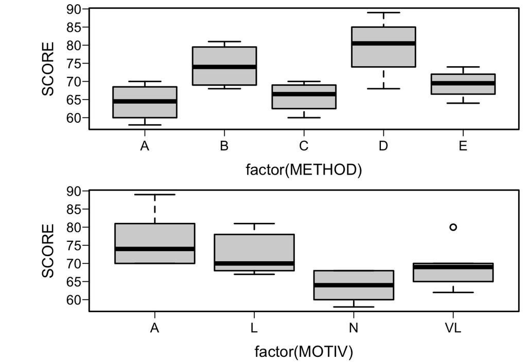

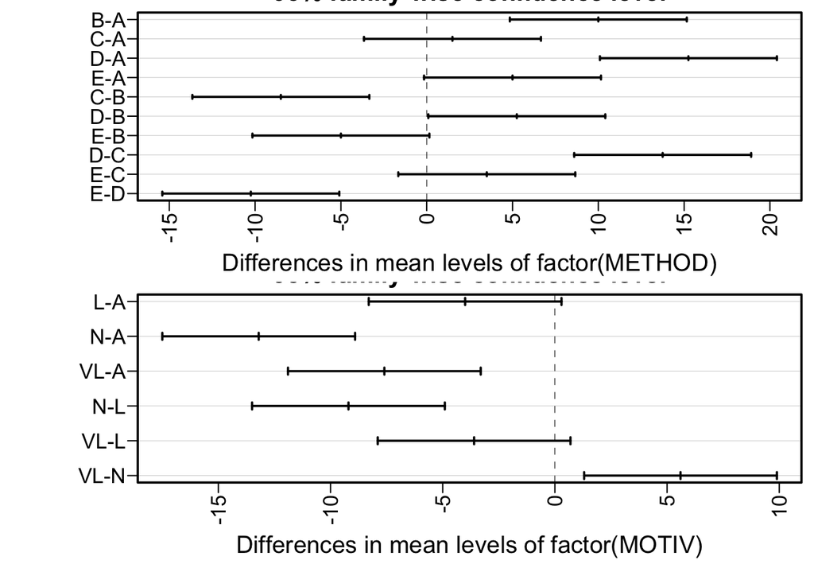

```r
plot(TukeyHSD(Exr3_3.aov), las=2)
```

## 2.4 EXERCISE 8.4.1

One of the purposes of a study by Liu et al. was to determine the effects of MRZ 2/579 on neurological deficit in Sprague-Dawley rats. In this study, 10 rats measured at four time periods following occlusion of the middle carotid artery and subsequent treatment with the uncompetitive N-metyl-D-aspartate antagonist MRZ 2/579, which previous studies had suggested provides neuroprotecive activity. The outcom varible was a neurological function variable measured on a scale of 0-12. A higher number indicates a higher degree of neurological imparement. Let $\alpha = .05$.

```r
setwd("~/Dropbox/Fdo/ClaseStats/RegressionClass/RegressionR_code")
# Exercise 8.4.1 ANOVA Single factor repeated measures
#
Exr4.1=read.csv(file="DataOther/EXR_C08_S04_01.csv", header=TRUE)
names(Exr4.1)
```

```
[1] "outcome" "subj"    "time"
```

```r
# outcome we want to estimate if depends on subj with
# repeated measurements in time for subj.
# factor is used to force the numbers as factors !
# And were grouped in time to measure effect
# model outcome ~ factor(subj) + factor(time)
layout(matrix(c(1,2), nrow=2, ncol=1, byrow=TRUE))
plot(outcome ~ factor(time) + factor(subj), data=Exr4.1)
Exr4.1.aov = aov(outcome ~ factor(time) + factor(subj), data=Exr4.1)
summary(Exr4.1.aov)
```

```
             Df Sum Sq Mean Sq F value   Pr(>F)
factor(time)  3 192.27   64.09  48.780 4.94e-11 ***
factor(subj)  9  64.22    7.14   5.431 0.000285 ***
Residuals    27  35.48    1.31
---
Signif. codes:  0 '***' 0.001 '**' 0.01 '*' 0.05 '.' 0.1 ' ' 1
```

```r
#
TukeyHSD(Exr4.1.aov)
```

```
  Tukey multiple comparisons of means
    95% family-wise confidence level

Fit: aov(formula = outcome ~ factor(time) + factor(subj), data = Exr4.1)

$`factor(time)`
    diff       lwr        upr     p adj
2-1 -3.5 -4.902813 -2.0971867 0.0000014
3-1 -4.8 -6.202813 -3.3971867 0.0000000
4-1 -5.8 -7.202813 -4.3971867 0.0000000
3-2 -1.3 -2.702813  0.1028133 0.0766789
4-2 -2.3 -3.702813 -0.8971867 0.0006614
4-3 -1.0 -2.402813  0.4028133 0.2314839

$`factor(subj)`
              diff        lwr         upr     p adj
2-1  -1.500000e+00 -4.2879369  1.28793688 0.6993512
3-1   7.500000e-01 -2.0379369  3.53793688 0.9940791
4-1  -3.000000e+00 -5.7879369 -0.21206312 0.0274633
5-1   1.750000e+00 -1.0379369  4.53793688 0.5055495
6-1  -1.250000e+00 -4.0379369  1.53793688 0.8630551
7-1  -7.500000e-01 -3.5379369  2.03793688 0.9940791
8-1  -7.500000e-01 -3.5379369  2.03793688 0.9940791
9-1  -1.000000e+00 -3.7879369  1.78793688 0.9597569
10-1  5.000000e-01 -2.2879369  3.28793688 0.9997409
3-2   2.250000e+00 -0.5379369  5.03793688 0.1946790
4-2  -1.500000e+00 -4.2879369  1.28793688 0.6993512
5-2   3.250000e+00  0.4620631  6.03793688 0.0131317
6-2   2.500000e-01 -2.5379369  3.03793688 0.9999993
7-2   7.500000e-01 -2.0379369  3.53793688 0.9940791
8-2   7.500000e-01 -2.0379369  3.53793688 0.9940791
9-2   5.000000e-01 -2.2879369  3.28793688 0.9997409
10-2  2.000000e+00 -0.7879369  4.78793688 0.3284340
4-3  -3.750000e+00 -6.5379369 -0.96206312 0.0028047
5-3   1.000000e+00 -1.7879369  3.78793688 0.9597569
6-3  -2.000000e+00 -4.7879369  0.78793688 0.3284340
7-3  -1.500000e+00 -4.2879369  1.28793688 0.6993512
8-3  -1.500000e+00 -4.2879369  1.28793688 0.6993512
9-3  -1.750000e+00 -4.5379369  1.03793688 0.5055495
10-3 -2.500000e-01 -3.0379369  2.53793688 0.9999993
5-4   4.750000e+00  1.9620631  7.53793688 0.0001155
6-4   1.750000e+00 -1.0379369  4.53793688 0.5055495
7-4   2.250000e+00 -0.5379369  5.03793688 0.1946790
8-4   2.250000e+00 -0.5379369  5.03793688 0.1946790
9-4   2.000000e+00 -0.7879369  4.78793688 0.3284340
10-4  3.500000e+00  0.7120631  6.28793688 0.0061224
6-5  -3.000000e+00 -5.7879369 -0.21206312 0.0274633
7-5  -2.500000e+00 -5.2879369  0.28793688 0.1070629
8-5  -2.500000e+00 -5.2879369  0.28793688 0.1070629
9-5  -2.750000e+00 -5.5379369  0.03793688 0.0554836
10-5 -1.250000e+00 -4.0379369  1.53793688 0.8630551
7-6   5.000000e-01 -2.2879369  3.28793688 0.9997409
8-6   5.000000e-01 -2.2879369  3.28793688 0.9997409
9-6   2.500000e-01 -2.5379369  3.03793688 0.9999993
10-6  1.750000e+00 -1.0379369  4.53793688 0.5055495
8-7  -8.881784e-16 -2.7879369  2.78793688 1.0000000
9-7  -2.500000e-01 -3.0379369  2.53793688 0.9999993
10-7  1.250000e+00 -1.5379369  4.03793688 0.8630551
9-8  -2.500000e-01 -3.0379369  2.53793688 0.9999993
10-8  1.250000e+00 -1.5379369  4.03793688 0.8630551
10-9  1.500000e+00 -1.2879369  4.28793688 0.6993512
```

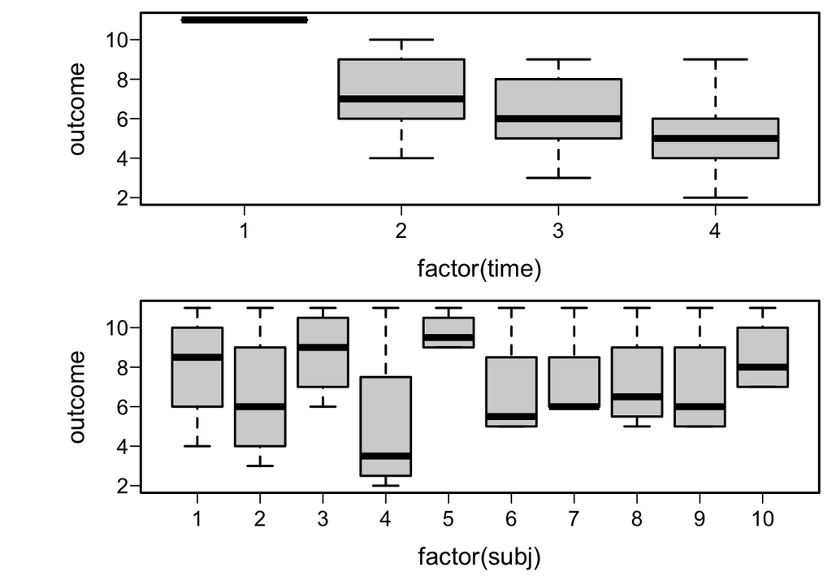

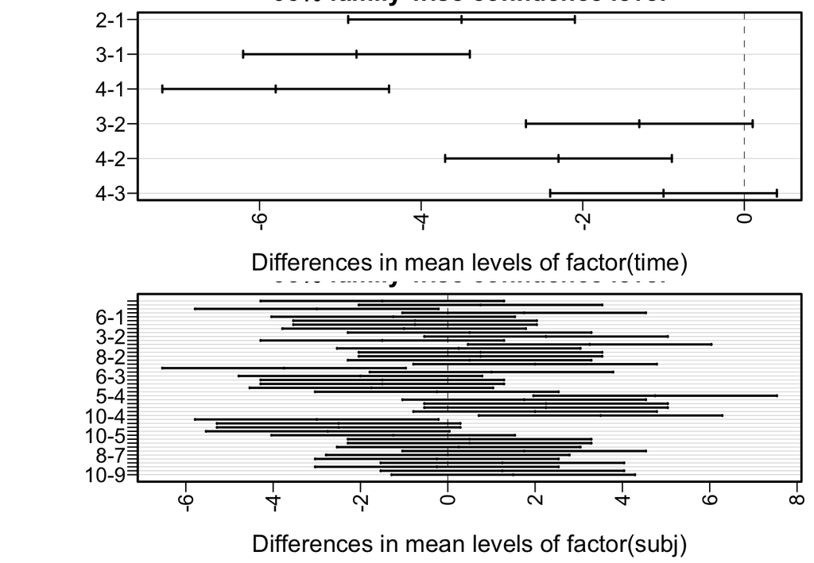

```r
plot(TukeyHSD(Exr4.1.aov), las=2)
```